# Topic1DQ1

"What are some examples of situations in which basic statistical concepts, such as population, sample, parameter, and statistic, could be useful for making decisions or drawing conclusions? How can Python be used to help analyze data in these situations?"

Python can be used to perform statistical tests and calculations to compare the average lifespans from the sample data, visualize lifespan distributions, and handle data preprocessing. Python can be used to perform statistical tests to infer about the population, and visualize the data for better understanding. Python libraries such as Pandas for data manipulation, NumPy for numerical calculations, Matplotlib and Seaborn for data visualization, and SciPy or Statsmodels for statistical analysis are typically used in these scenarios.

Comparing Lifespan of Different Dog Breeds Situation: A veterinary researcher wants to compare the lifespan of Labrador Retrievers and Beagles to understand breed-specific health trends.

```python
#import libraries
import matplotlib.pyplot as plt
import pandas as pd
import seaborn as sns

#import data
dog_data = pd.read_csv("C:/Users/khbil/Documents/GCU/DSC-510/Week_1/DQs/dog_breeds.csv")
dog_data['average_life_expectancy'] = (dog_data['min_life_expectancy'] + dog_data['max_life_expectancy']) / 2
print(dog_data.head)
```

```
<bound method NDFrame.head of                               Name  min_life_expectancy  max_life_expectancy  \
0                 Golden Retriever                   10                   12
1                        Dachshund                   12                   16
2               Labrador Retriever                   10                   12
3                       Great Dane                    7                   10
4                            Boxer                   10                   12
..                             ...                  ...                  ...
92  American Staffordshire Terrier                   12                   16
93             Australian Shepherd                   12                   15
94            Pembroke Welsh Corgi                   12                   13
95               Yorkshire Terrier                   11                   15
96                  French Bulldog                   10                   12

    max_height_male  max_height_female  max_weight_male  max_weight_female  \
0              24.0               24.0             75.0               65.0
```

[output cut: 51 more lines]

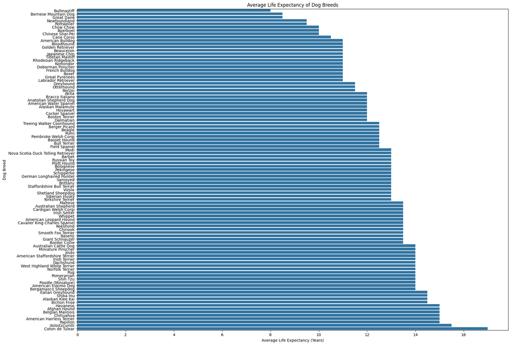

```python
# sort the data
dog_data_sorted = dog_data.sort_values(by='average_life_expectancy')

# create a bar chart
plt.figure(figsize=(20, 15))
sns.barplot(x='average_life_expectancy', y='Name', data=dog_data_sorted)
plt.xlabel('Average Life Expectancy (Years)')
plt.ylabel('Dog Breed')
plt.title('Average Life Expectancy of Dog Breeds')
plt.show()
```

```python
References

Q. Shen, "Research on Intelligent Matching Model Between Employees and Positions Based on Python Big Data Analysis," 2022 IEEE 4th Eurasia Conference on IOT,
    Communication and Engineering (ECICE), Yunlin, Taiwan, 2022, pp. 386-390, doi: 10.1109/ECICE55674.2022.10042840.

Rogel-Salazar, J. (2023). Snakes, Bears & Other Numerical Beasts: NumPy, SciPy & pandas. In Statistics and data visualisation with Python (1st ed.). CRC Press.


Data can be downloaded on Kaggle:
https://www.kaggle.com/datasets/warcoder/dog-breeds-details?resource=download
```